# SQL - Lenguaje de Consulta Estructurado

## Cláusula WHERE

### Selección de filas

Una vez que se han definido las columnas que se quieren seleccionar para la consulta, es posible que no se quieran todas las filas del conjunto de datos de origen.

La cláusula *WHERE* brinda la manera de seleccionar filas, pues contiene la lógica condicional necesaria para determinar que fila se incluirá en la salida de la consulta. Puede contener cualquier expresión válida de SAS.

Dentro de la consulta *SELECT FROM* la cláusula *WHERE* es opcional, si se incluye en una consulta debe ir siempre seguido a la cláusula FROM. El siguiente código SAS utiliza la clausula *WHERE* para seleccionar desde un conjunto de datos llamado “mundo” solo las filas que corresponden a los países que practican la religión “musulmana”.

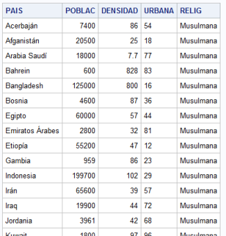

```r
    proc sql;
      select *
        from Datos.Mundo
        where relig eq 'Musulmana';
    quit;
```

La sintaxis de la cláusula *WHERE* admite más de una condición de selección para hacer que un registro sea incluido en la salida de la consulta. Cuando debe cumplirse más de una condición se utilizan los operadores lógicos *AND* y *OR* para agruparlas. Por ejemplo, si se quieren restringir la selección de filas desde el conjunto de datos “mundo” seleccionando solo los países que practican la religión “musulmana” y con un índice de alfabetización mayor a 50, se debe agregar la segunda condición a la cláusula *WHERE*:

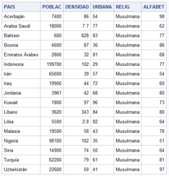

```r
    proc sql;
      select *
        from Datos.Mundo
          where relig eq 'Musulmana' and
            alfabet > 50;
    quit;
```

*Nota*: No hay límite para la cantidad de condiciones que puede tener la cláusula *WHERE*.

Existe una diferencia de cómo **SAS** maneja los tipos de datos cuando no coinciden en las cláusulas *WHERE* y otras partes del lenguaje. Esto se puede ver cuando se utiliza *WHERE* en *PROC SQL* o en un paso *DATA* u otro procedimiento. En la mayoría de los casos SAS realiza una conversión del tipo de dato en forma automática, de carácter a numérico o viceversa, para que la comparación tenga válidez y no presente un error. En siguiente ejemplo de código **SAS**, suponiendo que la variable “TPO” (Tiempo demora) es de tipo numérica, el paso *DATA* se ejecutará presentando una nota aclaratoria, pero la consulta **SQL** no:

```r
    data ResulData;
      set Datos.curso;
      if tpo > '20';
    run;
```

```r
    proc sql;
      create table ResulConsul as
      select *
        from Datos.curso
          where tpo > '20';
    quit;
```

En el paso *DATA* la instrucción *IF* realiza una conversión automática de ‘20’ a numérico y evalúa la expresión, pero escribe una *nota* en la ventana *Log* que indica lo siguiente:

```r
  NOTE: Character values have been converted to numeric values
        at the places given by: (Line) :(Column).
```

En una consulta **SQL** la cláusula *WHERE* requiere que el tipo de datos sea compatible, por tal motivo genera un error y no se ejecuta:

```r
ERROR: Expression using greater than (>) has components that are of different
data types.
```

El requisito de compatibilidad de datos de la cláusula *WHERE* es válido si se usa en una consulta **SQL**, paso *DATA* u otro procedimiento. Los mensajes de error escritos en la ventana Log pueden ser diferentes. Por ejemplo, al ejecutar el paso *DATA* anterior con una instrucción *WHERE* en lugar de una instrucción *IF* se genera un mensaje de error ligeramente diferente y el paso *DATA* no se ejecuta:

```r
    data ResulData;
      set Datos.curso;
      where tpo > '20';
    run;

    ERROR: WHERE clause operator requires compatible variables.
```

### Operadores especiales

Hay una serie de operadores que solo se pueden usar en una cláusula *WHERE*. Algunos de ellos pueden simplificar y hacer más eficiente la programación porque reducen el código necesaio para realizar algunas operaciones.

#### **IS NULL/IS MISSING**

Es posible usar los operadores *IS NULL* o *IS MISSING* para que devuelvan las filas con valores faltantes. La ventaja de *IS NULL* (o *IS MISSING*) es que la sintaxis es la misma si la variable es caracter o numérica.

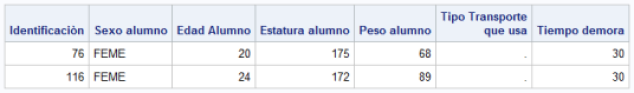

```r
    proc sql;
      select *
      from Datos.curso
      where tipotran is null;
    quit;
```

*Nota*: IS MISSING es una extensión específica de **SAS** para **SQL**.

En la mayoría de las implementaciones de bases de datos hay una distinción entre valores vacíos (faltantes) y valores nulos. Los valores nulos son un caso único y se comparan con éxito con cualquier cosa que no sean otros valores nulos. Se debe tener en cuenta cómo se manejan los valores nulos si se está utilizando **SQL** en un entorno que no sea SAS.

#### **BETWEEN**

El operador *BETWEEN* le permite buscar un valor que se encuentre entre otros dos valores.

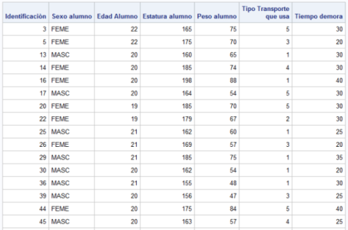

```r
    proc sql;
      select *
      from Datos.curso
      where tpo between 20 and 40;
    quit;
```

Cuando se usa *BETWEEN* hay que tener en cuenta que los puntos finales se incluyen en los resultados de la consulta. En el ejemplo anterior, 20 y 40 están incluidos. La variable utilizada con *BETWEEN* puede ser numérica o de caracteres. Hay que considerar los riesgos que existen al usar variables de tipo caracter en las comparaciones, es recomendable conocer cual es la clasificación que utiliza el sistema operativo, es decir, ¿“a” es mayor o menor que “A”? y también que, ” a” no es lo mismo que “a”.

Hay un comportamiento interesante del operador *BETWEEN*. Los valores se tratan como los límites de un rango y se colocan automáticamente en el orden correcto. Esto significa que las siguientes dos condiciones producen el mismo resultado:

```r
    where tpo between 20 and 40;
    where tpo between 40 and 20;
```

El orden en que se colocan los valores entre no es importante, aunque se recomienda que se especifiquen en la secuencia correcta para facilitar la comprensión.

### Ordenar datos

Tanto *SELECT… FROM…*, como *WHERE*, juegan un papel importante para determinar qué información se incluirá en los resultados de la consulta. La cláusula *ORDER BY* toma las filas seleccionadas y las ordena. La cláusula *ORDER BY* es opcional y, si se usa, debe estar seguida a la cláusula *WHERE*; si *WHERE* no se usa, debe seguir a la cláusula *FROM*.

```r
    proc sql;
        select *
        from Datos.Mundo
        where relig eq 'Musulmana'
        order by pais;
    quit;
```

Esta consulta selecciona todos los países que practican la religión Musulmana y los ordena por nombre del país.

[figure not shown]

Como se puede observar, la sintaxis de la cláusula **ORDER BY** es similar a la declaración **BY** de **PROC SORT**. Si se quieren ordenar las filas por más de una variable, las mismas se deben colocar en la secuencia de orden separadas por comas.

**Opción DESC en ORDER BY**

El orden de clasificación predeterminado es ascendente. Para obtener una clasificación descendente, se usa la opción **DESC** seguido al nombre de la variable.

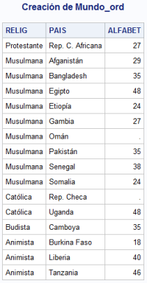

```r
    proc sql;
        create table Mundo_ord as
        select relig,
             pais,
             alfabet
        from Datos.Mundo
        where alfabet < 50
        order by relig desc,
                 pais;
    quit;
```

La opción **DESC** se puede agregar a tantas variables como sea necesario, siempre después del nombre de la variable y antes de la coma o punto y coma.